# Part I - Ford GoBike System Data Exploration

## Introduction

This project explores the Ford GoBike System Data. The dataset contains individual bike-share trips from the greater San Francisco Bay Area during February 2019.

The main goal of this exploration is to understand trip behavior. I will focus on trip duration, user type, member gender, start hour, day of week, and member age.

The main questions I want to answer are:

1. How long are most bike trips?
2. Are most trips taken by subscribers or customers?
3. How does trip duration vary by user type?
4. When are trips most common by hour and day of week?
5. Do age, gender, and user type show any visible relationship with trip duration?

## Preliminary Wrangling

In this section, I load the dataset, check its structure, and create new fields that will help with visualization. I create trip duration in minutes, member age, start hour, and day of week.

```python
# import all packages and set plots to be embedded inline
import numpy as np
import pandas as pd
import matplotlib.pyplot as plt
import seaborn as sns
import warnings

%matplotlib inline

# Suppress warnings from the final notebook output
warnings.simplefilter("ignore")

# Set plot style
sns.set_style('whitegrid')
```

```python
def clean_gobike_data(file_path):
    """
    Load, clean, and prepare Ford GoBike data for analysis.

    Returns the raw dataset, a cleaned dataset, and a typical-trip dataset
    filtered to trips of 60 minutes or less.
    """
    rides = pd.read_csv(file_path)

    # Convert time columns to datetime
    rides['start_time'] = pd.to_datetime(rides['start_time'])
    rides['end_time'] = pd.to_datetime(rides['end_time'])

    # Create analysis fields
    rides['duration_min'] = rides['duration_sec'] / 60
    rides['member_age'] = 2019 - rides['member_birth_year']
    rides['start_hour'] = rides['start_time'].dt.hour
    rides['day_of_week'] = rides['start_time'].dt.day_name()

    # Order days of the week for plots
    ordered_days = ['Monday', 'Tuesday', 'Wednesday', 'Thursday', 'Friday', 'Saturday', 'Sunday']
    rides['day_of_week'] = pd.Categorical(rides['day_of_week'], categories=ordered_days, ordered=True)

    # Convert repeated text fields to categories using a loop
    category_columns = ['user_type', 'member_gender', 'bike_share_for_all_trip']
    for col in category_columns:
        rides[col] = rides[col].astype('category')

    # Remove rows that are missing fields needed for this analysis
    clean = rides.dropna(subset=[
        'member_birth_year',
        'member_gender',
        'start_station_name',
        'end_station_name'
    ]).copy()

    # Keep reasonable member ages for this analysis
    clean = clean[clean['member_age'].between(18, 80)]

    # Use typical trips for most visualizations so extreme trips do not distort the charts
    typical = clean[clean['duration_min'] <= 60].copy()

    return rides, clean, typical


def add_bar_labels(ax):
    """
    Add count labels above bars in a bar chart.

    Parameters
    ----------
    ax : matplotlib Axes
        The chart axis where labels should be added.
    """
    for bar in ax.patches:
        height = bar.get_height()
        ax.text(
            bar.get_x() + bar.get_width() / 2,
            height,
            f'{int(height):,}',
            ha='center',
            va='bottom',
            fontsize=10
        )


def format_plot(title, xlabel, ylabel):

    # Apply consistent titles, labels, and layout to plots.

    plt.title(title, fontsize=14, fontweight='bold')
    plt.xlabel(xlabel, fontsize=11)
    plt.ylabel(ylabel, fontsize=11)
    plt.tight_layout()


rides_raw, rides_clean, rides_typical = clean_gobike_data('fordgobike-tripdata.csv')
```

```python
# High-level overview of data shape, data types, and first few rows
print(rides_raw.shape)
print(rides_raw.dtypes)
rides_raw.head()
```

```
(183412, 20)
duration_sec                        int64
start_time                 datetime64[ns]
end_time                   datetime64[ns]
start_station_id                  float64
start_station_name                 object
start_station_latitude            float64
start_station_longitude           float64
end_station_id                    float64
end_station_name                   object
end_station_latitude              float64
end_station_longitude             float64
bike_id                             int64
user_type                        category
member_birth_year                 float64
member_gender                    category
bike_share_for_all_trip          category
duration_min                      float64
member_age                        float64
start_hour                          int32
day_of_week                      category
dtype: object
```

|  | duration_sec | start_time | end_time | start_station_id | start_station_name | start_station_latitude | start_station_longitude | end_station_id | end_station_name | end_station_latitude | end_station_longitude | bike_id | user_type | member_birth_year | member_gender | bike_share_for_all_trip | duration_min | member_age | start_hour | day_of_week |
| --- | --- | --- | --- | --- | --- | --- | --- | --- | --- | --- | --- | --- | --- | --- | --- | --- | --- | --- | --- | --- |
| 0 | 52185 | 2019-02-28 17:32:10.145 | 2019-03-01 08:01:55.975 | 21.0 | Montgomery St BART Station (Market St at 2nd St) | 37.789625 | -122.400811 | 13.0 | Commercial St at Montgomery St | 37.794231 | -122.402923 | 4902 | Customer | 1984.0 | Male | No | 869.750000 | 35.0 | 17 | Thursday |
| 1 | 42521 | 2019-02-28 18:53:21.789 | 2019-03-01 06:42:03.056 | 23.0 | The Embarcadero at Steuart St | 37.791464 | -122.391034 | 81.0 | Berry St at 4th St | 37.775880 | -122.393170 | 2535 | Customer | NaN | NaN | No | 708.683333 | NaN | 18 | Thursday |
| 2 | 61854 | 2019-02-28 12:13:13.218 | 2019-03-01 05:24:08.146 | 86.0 | Market St at Dolores St | 37.769305 | -122.426826 | 3.0 | Powell St BART Station (Market St at 4th St) | 37.786375 | -122.404904 | 5905 | Customer | 1972.0 | Male | No | 1030.900000 | 47.0 | 12 | Thursday |
| 3 | 36490 | 2019-02-28 17:54:26.010 | 2019-03-01 04:02:36.842 | 375.0 | Grove St at Masonic Ave | 37.774836 | -122.446546 | 70.0 | Central Ave at Fell St | 37.773311 | -122.444293 | 6638 | Subscriber | 1989.0 | Other | No | 608.166667 | 30.0 | 17 | Thursday |
| 4 | 1585 | 2019-02-28 23:54:18.549 | 2019-03-01 00:20:44.074 | 7.0 | Frank H Ogawa Plaza | 37.804562 | -122.271738 | 222.0 | 10th Ave at E 15th St | 37.792714 | -122.248780 | 4898 | Subscriber | 1974.0 | Male | Yes | 26.416667 | 45.0 | 23 | Thursday |

```python
# Check missing values
rides_raw.isnull().sum()
```

```
duration_sec                  0
start_time                    0
end_time                      0
start_station_id            197
start_station_name          197
start_station_latitude        0
start_station_longitude       0
end_station_id              197
end_station_name            197
end_station_latitude          0
end_station_longitude         0
bike_id                       0
user_type                     0
member_birth_year          8265
member_gender              8265
bike_share_for_all_trip       0
duration_min                  0
member_age                 8265
start_hour                    0
day_of_week                   0
dtype: int64
```

```python
# Summary statistics for the cleaned typical-trip dataset
print(rides_clean.shape)
print(rides_typical.shape)
rides_typical[['duration_min', 'member_age', 'start_hour']].describe()
```

```
(174760, 20)
(173374, 20)
```

|  | duration_min | member_age | start_hour |
| --- | --- | --- | --- |
| count | 173374.000000 | 173374.000000 | 173374.000000 |
| mean | 10.311936 | 34.119389 | 13.456931 |
| std | 7.396501 | 9.873882 | 4.739245 |
| min | 1.016667 | 18.000000 | 0.000000 |
| 25% | 5.366667 | 27.000000 | 9.000000 |
| 50% | 8.450000 | 32.000000 | 14.000000 |
| 75% | 13.000000 | 39.000000 | 17.000000 |
| max | 59.933333 | 80.000000 | 23.000000 |

### What is the structure of your dataset?

The original dataset contains 183,412 trips and 16 columns. After loading the data, I created four additional analysis fields: duration in minutes, member age, start hour, and day of week.

The cleaned dataset removes rows missing member birth year, member gender, start station name, or end station name. I also filtered member age to 18 through 80. For the visual analysis, I use a typical-trip dataset that keeps trips of 60 minutes or less because very long trips make the duration plots harder to read.

### What is/are the main feature(s) of interest in your dataset?

The main feature of interest is trip duration in minutes. I also want to understand how usage patterns differ by user type and time of day.

### What features in the dataset do you think will help support your investigation into your feature(s) of interest?

The supporting features are user type, member gender, member age, start hour, day of week, and bike share for all trip.

## Univariate Exploration

In this section, I look at one variable at a time.

Assumptions and questions:

1. Most trips are probably short because bike-share systems are often used for quick trips.
2. Subscribers likely make up most of the trips.

### Question 1

How long are most typical Ford GoBike trips?

### Visualization

The histogram below shows the distribution of trip duration in minutes for typical trips of 60 minutes or less.

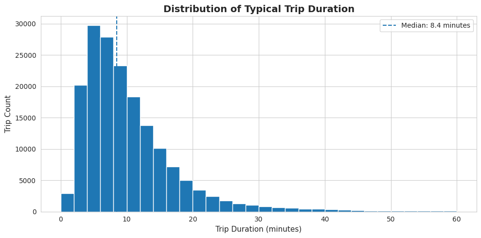

```python
plt.figure(figsize=(10, 5))

bins = np.arange(0, rides_typical['duration_min'].max() + 2, 2)
plt.hist(rides_typical['duration_min'], bins=bins)

median_duration = rides_typical['duration_min'].median()
plt.axvline(
    median_duration,
    linestyle='--',
    label=f'Median: {median_duration:.1f} minutes'
)

format_plot(
    'Distribution of Typical Trip Duration',
    'Trip Duration (minutes)',
    'Trip Count'
)

plt.legend()
plt.show()
```

### Observations

Most trips are short. The distribution is right-skewed, with many trips under 15 minutes and fewer trips as duration increases. The median trip duration is about 8.5 minutes. I used the 60-minute typical-trip filter because extreme long trips make the main distribution harder to see.

### Question 2

Are most trips taken by subscribers or customers?

### Visualization

The bar chart below compares trip counts by user type.

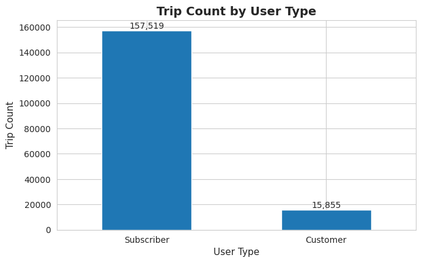

```python
plt.figure(figsize=(7, 5))

user_counts = rides_typical['user_type'].value_counts()
ax = user_counts.plot(kind='bar')

add_bar_labels(ax)

format_plot(
    'Trip Count by User Type',
    'User Type',
    'Trip Count'
)

plt.xticks(rotation=0)
plt.show()
```

### Observations

Most trips are taken by subscribers. Customers make up a much smaller portion of the trips. This suggests the system is used heavily by regular or commuting users.

### Discuss the distribution(s) of your variable(s) of interest. Were there any unusual points? Did you need to perform any transformations?

Trip duration has a right-skewed distribution. Most trips are short, while a small number of trips are much longer. I did not use a log transformation because the main project questions can be answered clearly by filtering to typical trips of 60 minutes or less.

### Of the features you investigated, were there any unusual distributions? Did you perform any operations on the data to tidy, adjust, or change the form of the data? If so, why did you do this?

User type is very uneven because subscribers make up most trips. I created new fields for duration in minutes, member age, start hour, and day of week. I also filtered member age to 18 through 80 and used typical trips of 60 minutes or less so the visualizations would be easier to interpret.

## Bivariate Exploration

Assumptions and questions:

1. Customers may take longer trips than subscribers.
2. Trip activity may be higher during commute hours.
3. Age may not have a strong relationship with trip duration.

### Question 3

Does member age appear related to trip duration?

### Visualization

The scatter plot below shows member age compared with trip duration. Jitter is used to reduce overplotting around each age value.

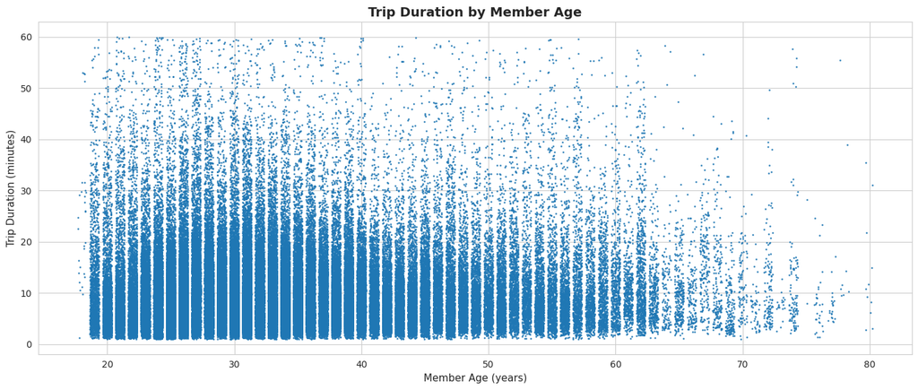

```python
plt.figure(figsize=(14, 6))

sns.regplot(
    data=rides_typical,
    x='member_age',
    y='duration_min',
    fit_reg=False,
    x_jitter=0.35,
    scatter_kws={'s': 1}
)

format_plot(
    'Trip Duration by Member Age',
    'Member Age (years)',
    'Trip Duration (minutes)'
)

plt.show()
```

### Observations

There is no strong visible relationship between member age and trip duration. Most trips are short across many age groups. The densest area appears among riders between about 25 and 40 years old.

### Question 4

How does trip duration vary by user type?

### Visualization

The box plot below compares trip duration between subscribers and customers.

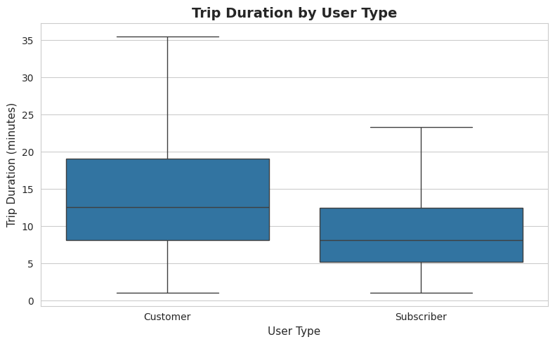

```python
plt.figure(figsize=(8, 5))

sns.boxplot(
    data=rides_typical,
    x='user_type',
    y='duration_min',
    showfliers=False,
    color=sns.color_palette()[0]
)

format_plot(
    'Trip Duration by User Type',
    'User Type',
    'Trip Duration (minutes)'
)

plt.show()
```

### Observations

Customers generally take longer trips than subscribers. Subscribers have a lower median trip duration, which supports the idea that many subscribers use the system for shorter routine trips.

### Question 5

When are trips most common by day of week and time period?

### Visualization

The clustered bar chart below shows trip counts by day of week and time period.

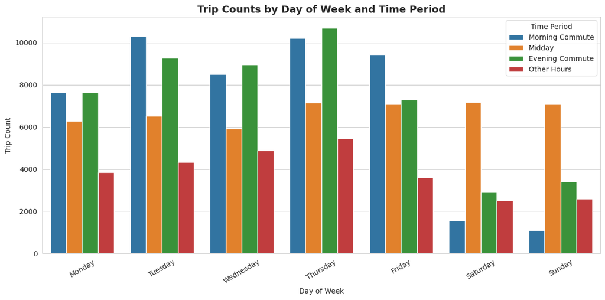

```python
def assign_time_period(hour):
    """
    Group trip start hours into simple daily time periods.
    """
    if 6 <= hour <= 9:
        return 'Morning Commute'
    elif 10 <= hour <= 15:
        return 'Midday'
    elif 16 <= hour <= 18:
        return 'Evening Commute'
    else:
        return 'Other Hours'


rides_typical['time_period'] = rides_typical['start_hour'].apply(assign_time_period)

period_order = ['Morning Commute', 'Midday', 'Evening Commute', 'Other Hours']

period_day_counts = (
    rides_typical
    .groupby(['day_of_week', 'time_period'])
    .size()
    .reset_index(name='trip_count')
)

plt.figure(figsize=(12, 6))

sns.barplot(
    data=period_day_counts,
    x='day_of_week',
    y='trip_count',
    hue='time_period',
    hue_order=period_order
)

plt.title('Trip Counts by Day of Week and Time Period', fontsize=14, fontweight='bold')
plt.xlabel('Day of Week')
plt.ylabel('Trip Count')
plt.xticks(rotation=30)
plt.legend(title='Time Period')

plt.tight_layout()
plt.show()
```

### Observations

Trip counts are highest during weekday commute periods, especially during the morning and evening commute windows. Weekend trip counts are lower and less concentrated around commute times. This supports the idea that Ford GoBike was used heavily for weekday commuting.

### Talk about some of the relationships you observed in this part of the investigation. How did the feature(s) of interest vary with other features in the dataset?

Trip duration varies by user type. Customers tend to take longer trips than subscribers, while subscribers take more trips overall. Trip count also varies by time, with clear weekday commute peaks around 8 AM and 5 PM.

### Did you observe any interesting relationships between the other features (not the main feature(s) of interest)?

The clustered bar chart shows that day of week and time period work together. Weekdays have strong commute-period patterns, while weekends are lower and more spread out.

## Multivariate Exploration

Assumptions and questions:

1. Subscribers and customers may have different hourly usage patterns.
2. User type may explain more of the trip duration difference than age or gender.

### Question 6

Do subscribers and customers use the system at different hours?

### Visualization

The facet plot below compares start hour distributions for subscribers and customers.

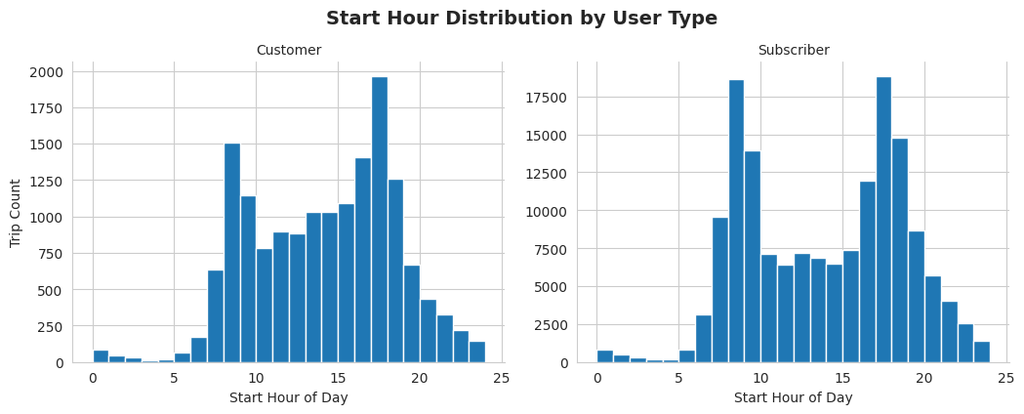

```python
g = sns.FacetGrid(
    data=rides_typical,
    col='user_type',
    height=4,
    aspect=1.3,
    sharey=False
)

g.map(plt.hist, 'start_hour', bins=np.arange(0, 25, 1))

g.set_axis_labels('Start Hour of Day', 'Trip Count')
g.set_titles('{col_name}')
g.fig.suptitle(
    'Start Hour Distribution by User Type',
    y=1.05,
    fontsize=14,
    fontweight='bold'
)

plt.show()
```

### Observations

Subscribers show clear peaks during commute hours, especially in the morning and late afternoon. Customers have lower total volume and a less dramatic commute pattern. This supports the finding that subscribers are more likely to be routine users.

### Question 7

How do age and user type appear together in relation to trip duration?

### Visualization

The plot below uses multiple encodings. Age is shown on the x-axis, trip duration is shown on the y-axis, and user type is shown with color. Jitter and dodge are used to reduce overplotting around each age value.

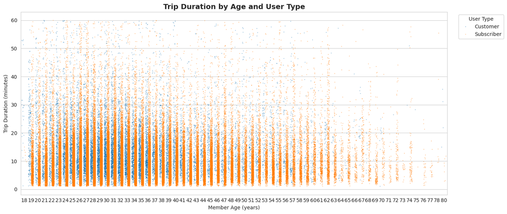

```python
# Convert member age to integer so jitter can spread points around each age value
rides_typical['member_age_int'] = rides_typical['member_age'].astype(int)

plt.figure(figsize=(14, 6))

sns.stripplot(
    data=rides_typical,
    x='member_age_int',
    y='duration_min',
    hue='user_type',
    jitter=0.35,
    dodge=True,
    size=1
)

plt.title('Trip Duration by Age and User Type', fontsize=14, fontweight='bold')
plt.xlabel('Member Age (years)')
plt.ylabel('Trip Duration (minutes)')
plt.legend(
    title='User Type',
    bbox_to_anchor=(1.02, 1),
    loc='upper left'
)

plt.tight_layout()
plt.show()
```

### Observations

The clearest separation is by user type. Customers appear more often at longer trip durations, while subscribers are more concentrated at shorter durations. Age does not show as clear of a pattern as user type.

### Talk about some of the relationships you observed in this part of the investigation. Were there features that strengthened each other in terms of looking at your feature(s) of interest?

User type and start hour strengthen each other. Subscribers show strong commute-hour usage, which supports the earlier finding that subscribers are likely regular users. User type also helps explain trip duration because customers tend to take longer trips.

## Conclusions

During the exploration, I created new time and demographic fields, removed missing demographic and station records, filtered unreasonable ages, and focused the visual analysis on typical trips of 60 minutes or less. This made the plots easier to interpret while still preserving the main usage patterns in the dataset.

```python
!jupyter nbconvert --to html "Part_I_notebook.ipynb"
```

```
[NbConvertApp] Converting notebook Part_I_notebook.ipynb to html
[NbConvertApp] WARNING | Alternative text is missing on 7 image(s).
[NbConvertApp] Writing 1474114 bytes to Part_I_notebook.html
```